# Project_4_2064_debajit2 : Movie Recommendation

Debajit Mitra

2022-12-01

```r
start_time <- Sys.time()

library(recommenderlab)
```

```r
library(ggplot2)
library(data.table)
library(reshape2)
library(knitr)
```

### Project Overview

In this project, I developed content based recommendation system(System I) and collaborative recommendation system(System II) .

- **System I:** Recommendation based on genres. Below two recommendation approaches are implemented using user’s favorite genre :
  - **Method I:** Highly-rate movies - select the 4 or more review
  - **Method II:** Most trendy movies - the newest movie
- **System II:** Collaborative recommendation system. Two collaborative recommendation algorithms are implemented :
  - **User-based (UBCF):** UBCF recommends items by finding similar users to the user with assumption that similar users will have similar taste.
  - **Item-based (IBCF):** IBCF recommends items by finding similarities between different items in the data, using Euclidean Distance similarity measures.

```r
set.seed(2064)
read <- function(fileName, separators) {
    data <- readLines(con <- file(fileName))
    close(con)
    records <- sapply(data, strsplit, split=separators)
    dataFrame <- data.frame(t(sapply(records,c)))
    rownames(dataFrame) <- 1: nrow(dataFrame)
    return(as.data.frame(dataFrame,stringsAsFactors = FALSE))
}


basedir ="data/"
movies = read(paste0(basedir,"movies.dat"), "::")
ratings = read(paste0(basedir,"ratings.dat"), "::")
users = read(paste0(basedir, "users.dat"), "::")
colnames(movies) = c('MovieID', 'title', 'genres')
colnames(ratings) = c('UserID', 'MovieID', 'Rating', 'Timestamp')
colnames(users) = c('UserID', 'Gender', 'Age', 'Occupation', 'Zip-code')

moviesList <- read(paste0(basedir,"aggr.dat"), "::")
movies_clean <- read(paste0(basedir,"movies_clean.dat"), "::")

colnames(moviesList) = c( 'MovieID', 'AveRating', 'title', 'genres')
colnames(movies_clean) = c("MovieID", "title", "year", 'genres')
genre_list <- c("Action", "Adventure", "Animation", "Children",
                "Comedy", "Crime","Documentary", "Drama", "Fantasy",
                "Film-Noir", "Horror", "Musical", "Mystery","Romance",
                "Sci-Fi", "Thriller", "War", "Western")
```

### Dataset

The dataset contains about 1 million ratings and the details as following:

- Number of movies: $3883$
- Number of ratings: $1000209$
- Number of users: $6040$

The dataset README shows: Genres are pipe-separated and are selected from the following genres:

- Action
- Adventure
- Animation
- Children’s
- Comedy
- Crime
- Documentary
- Drama
- Fantasy
- Film-Noir
- Horror
- Musical
- Mystery
- Romance
- Sci-Fi
- Thriller
- War
- Western

```r
genres <- as.data.frame(movies[,3], stringsAsFactors=FALSE)
genres2 <- as.data.frame(tstrsplit(genres[,1], '[|]', type.convert=TRUE), stringsAsFactors=FALSE)
colnames(genres2)<- c(1:5)

genre_list <- c("Action", "Adventure", "Animation", "Children",
                "Comedy", "Crime","Documentary", "Drama", "Fantasy",
                "Film-Noir", "Horror", "Musical", "Mystery","Romance",
                "Sci-Fi", "Thriller", "War", "Western")


genre_matrix <- matrix(0,nrow(movies) + 1,18)
genre_matrix[1,] <- genre_list
colnames(genre_matrix) <- genre_list

for (i in 1:nrow(genres2)) {
  for (c in 1:ncol(genres2)) {
    genmat_col = which(genre_matrix[1,] == genres2[i,c])
    genre_matrix[i+1,genmat_col] <- 1
  }
}

genre_matrix2 <- as.data.frame(genre_matrix[-1,], stringsAsFactors=FALSE)
for (c in 1:ncol(genre_matrix2)) {
  genre_matrix2[,c] <- as.integer(genre_matrix2[,c])
}

years <- as.data.frame(movies$title, stringsAsFactors=FALSE)

substrRight <- function(x, n){
  substr(x, nchar(x)-n+1, nchar(x))
}

years <- as.data.frame(substr(substrRight(substrRight(years$`movies$title`, 6),5),1,4))
colMin <- function(data) sapply(data, min, na.rm = TRUE)
colMax <- function(data) sapply(data, max, na.rm = TRUE)

min_year = colMin(years)
max_year = colMax(years)
```

The movies’ year are between $1919$ to $2000$.

```r
binaryratings <- ratings



for (i in 1:nrow(binaryratings)){
  if (binaryratings[i,3] > 3){
    binaryratings[i,3] <- 1
  }
  else{
    binaryratings[i,3] <- -1
  }
}

binaryratings2 <- dcast(binaryratings, MovieID~UserID, value.var = "Rating", na.rm=FALSE)



for (i in 1:ncol(binaryratings2)){
  binaryratings2[which(is.na(binaryratings2[,i]) == TRUE),i] <- 0
}
binaryratings2 = binaryratings2[,-1]

MovieIDs <- length(unique(movies$MovieID))
ratingMovieIDs <- length(unique(ratings$MovieID))
movies2 <- movies[-which((movies$MovieID %in% ratings$MovieID) == FALSE),]
rownames(movies2) <- NULL

genre_matrix3 <- genre_matrix2[-which((movies$MovieID %in% ratings$MovieID) == FALSE),]
rownames(genre_matrix3) <- NULL

result = matrix(0,18,nrow(users))
for (c in 1:ncol(binaryratings2)){
  for (i in 1:ncol(genre_matrix3)){
    result[i,c] <- sum((genre_matrix3[,i]) * (as.numeric(binaryratings2[,c])))
  }
}

for (c in 1:ncol(result)){
  for (i in 1:nrow(result)){
    if (result[i,c] < 0){
      result[i,c] <- 0
    }
    else {
      result[i,c] <- 1
    }
  }
}

ratingmat <- dcast(ratings, UserID~MovieID, value.var = "Rating", na.rm=FALSE)
ratingmat <- as.matrix(ratingmat[,-1])

ratingmat <- as(ratingmat, "realRatingMatrix")

similarity_users <- similarity(ratingmat[1:4, ],
                               method = "cosine",
                               which = "users")
as.matrix(similarity_users)
```

```
##           1         2         3         4
## 1        NA 0.9879233 0.9906542 0.9896170
## 2 0.9879233        NA 0.9785358 0.9844432
## 3 0.9906542 0.9785358        NA 0.9911817
## 4 0.9896170 0.9844432 0.9911817        NA
```

### Exploring Similarity Data

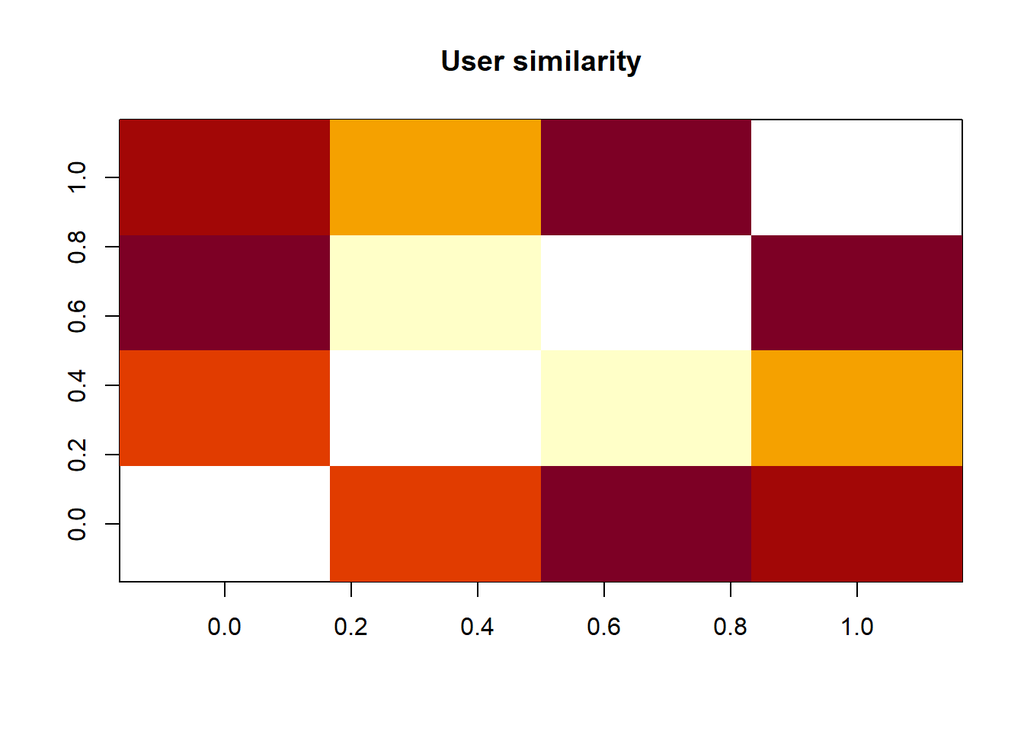

```r
image(as.matrix(similarity_users), main = "User similarity")
```

```r
similarity_items <- similarity(ratingmat[, 1:4], method =
                                 "cosine", which = "items")
as.matrix(similarity_items)
```

```
##              1        10       100      1000
## 1           NA 0.9779995 0.9661666 0.9891859
## 10   0.9779995        NA 0.9719863 0.9635863
## 100  0.9661666 0.9719863        NA 0.9558852
## 1000 0.9891859 0.9635863 0.9558852        NA
```

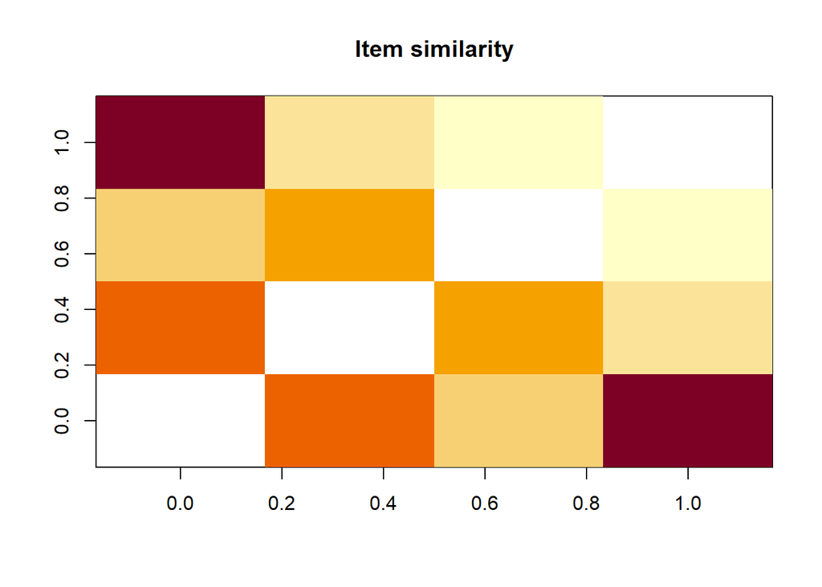

```r
image(as.matrix(similarity_items), main = "Item similarity")
```

### Most Viewed Movies Visualization

```r
vector_ratings <- as.vector(ratingmat@data)
unique(vector_ratings)
```

```
## [1] 5 0 4 2 3 1
```

```r
table_ratings <- table(vector_ratings)
table_ratings
```

```
## vector_ratings
##        0        1        2        3        4        5
## 21384031    56174   107557   261197   348971   226310
```

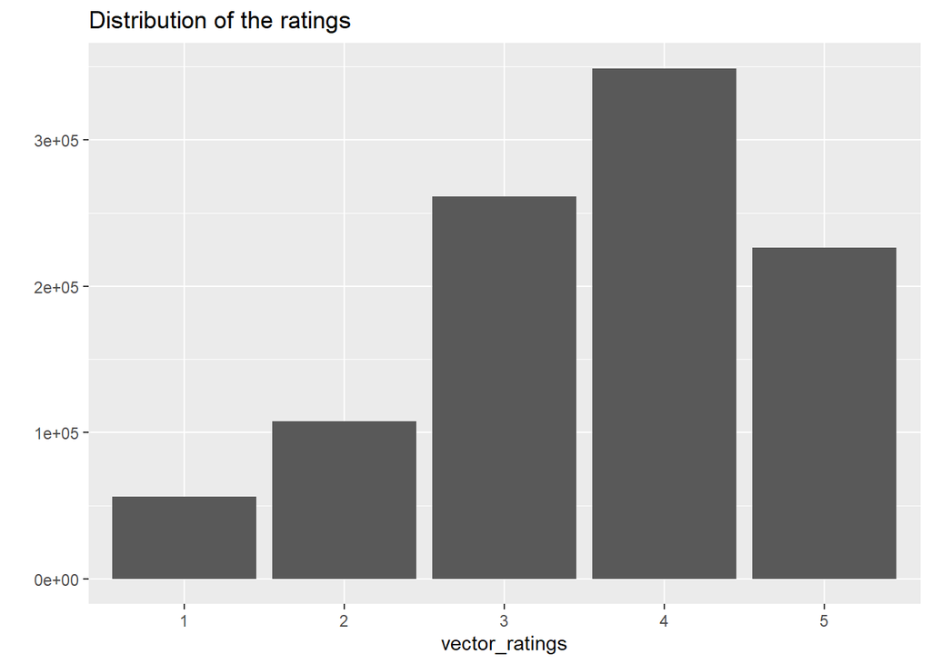

```r
vector_ratings <- vector_ratings[vector_ratings != 0]
vector_ratings <- factor(vector_ratings)

qplot(vector_ratings) +
  ggtitle("Distribution of the ratings")
```

```r
views_per_movie <- colCounts(ratingmat)
table_views <- data.frame(movie = names(views_per_movie), views = views_per_movie)
table_views <- table_views[order(table_views$views, decreasing = TRUE), ]
```

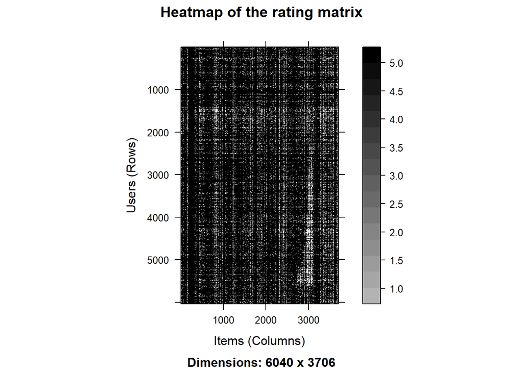

```r
#Visualizing the matrix:
image(ratingmat, main = "Heatmap of the rating matrix") # hard to read-too many dimensions
```

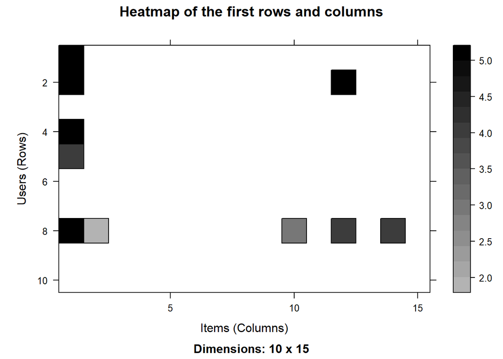

```r
image(ratingmat[1:10, 1:15], main = "Heatmap of the first rows and columns")
```

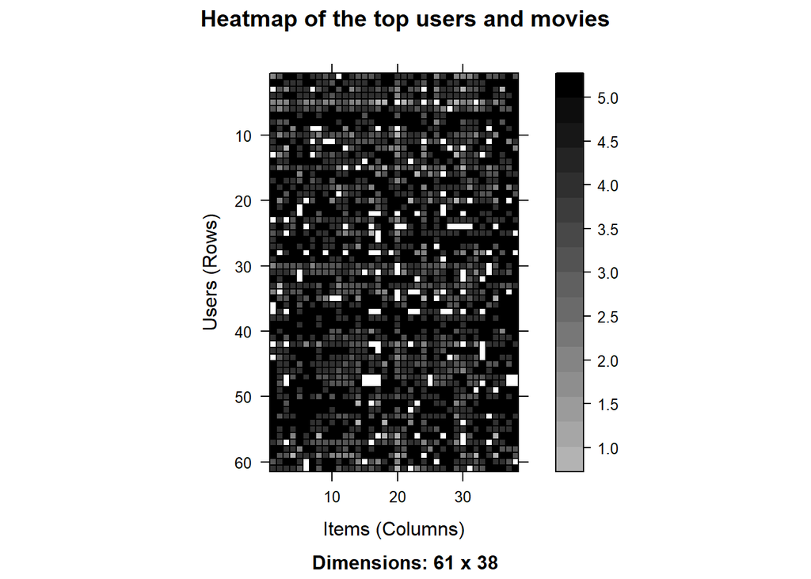

```r
image(ratingmat[rowCounts(ratingmat) > quantile(rowCounts(ratingmat), 0.99),
                 colCounts(ratingmat) > quantile(colCounts(ratingmat), 0.99)],
      main = "Heatmap of the top users and movies")
```

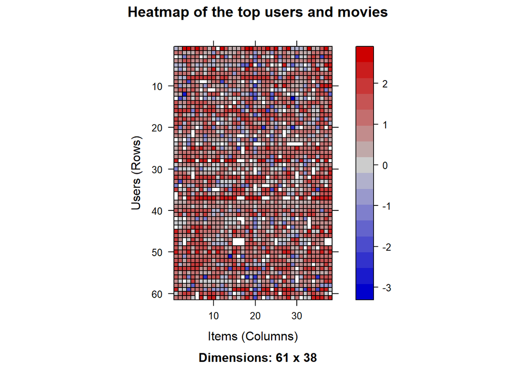

```r
#Normalize the data
ratingmat_norm <- normalize(ratingmat)
image(ratingmat_norm[rowCounts(ratingmat_norm) > quantile(rowCounts(ratingmat_norm), 0.99),
                colCounts(ratingmat_norm) > quantile(colCounts(ratingmat_norm), 0.99)],
      main = "Heatmap of the top users and movies")
```

## System I

system I is content based recommendation system, where movies will be recommended to the user based on user’s favorite genre.

### Method I: Highly-rate movies

The average point of each movie is calculated and N movies are randomly picked whose average point is great or equal to 4-point in the genres.

```r
  # Method 1:
  numberofmovierecommend = 5

  input_genre1 = genre_list[1]
  input_genre2 = genre_list[2]
  input_genre3 = genre_list[3]

  systemresult = subset(moviesList,AveRating>=4 & (grepl(input_genre1, genres, fixed = TRUE) | grepl(input_genre2, genres, fixed = TRUE) | grepl(input_genre3, genres, fixed = TRUE)) )
  if (nrow(systemresult) < numberofmovierecommend){
     systemresult = subset(moviesList, grepl(input_genre1, genres, fixed = TRUE) | grepl(input_genre2, genres, fixed = TRUE) | grepl(input_genre3, genres, fixed = TRUE))
  }

  systemresult = systemresult[sample(nrow(systemresult), ifelse(nrow(systemresult)>=numberofmovierecommend,numberofmovierecommend,nrow(systemresult))),]
  systemresult
```

```
##          MovieID AveRating title
## 11500381    3178         4  2886
## 12805029    3530         4  2846
## 142520        37         4  2800
## 6837058     1940         4  3046
## 11917316    3295         4   392
##                                                              genres
## 11500381               Adventures of Elmo in Grouchland, The (1999)
## 12805029                    Adventures of Milo and Otis, The (1986)
## 142520                Little Nemo: Adventures in Slumberland (1992)
## 6837058  Incredibly True Adventure of Two Girls in Love, The (1995)
## 11917316                 Secret Adventures of Tom Thumb, The (1993)
##                            NA
## 11500381    Children's|Comedy
## 12805029           Children's
## 142520   Animation|Children's
## 6837058        Comedy|Romance
## 11917316 Adventure|Children's
```

### Method II: Most trendy movies

The newest movies are from year 2000 in the dataset, N movies will be randomly picked from year 2000 in that genres,

```r
  # Method 2:
  numberofmovierecommend = 5
  trendyYear = 2000

  input_genre1 = genre_list[1]
  input_genre2 = genre_list[2]
  input_genre3 = genre_list[3]


  systemresult = subset(movies_clean, year >= trendyYear & (grepl(input_genre1, genres, fixed = TRUE) | grepl(input_genre2, genres, fixed = TRUE) | grepl(input_genre3, genres, fixed = TRUE)) )
  if (nrow(systemresult) < numberofmovierecommend){
      systemresult = subset(movies_clean, year >= trendyYear - 1 & (grepl(input_genre1, genres, fixed = TRUE) | grepl(input_genre2, genres, fixed = TRUE) | grepl(input_genre3, genres, fixed = TRUE)) )
  }
  systemresult = systemresult[sample(nrow(systemresult), ifelse(nrow(systemresult)>=numberofmovierecommend,numberofmovierecommend,nrow(systemresult))),]
  systemresult
```

```
##      MovieID                     title year          genres
## 3487    3555              U-571 (2000) 2000 Action|Thriller
## 3248    3316     Reindeer Games (2000) 2000 Action|Thriller
## 3232    3300        Pitch Black (2000) 2000   Action|Sci-Fi
## 3758    3827      Space Cowboys (2000) 2000   Action|Sci-Fi
## 3649    3717 Gone in 60 Seconds (2000) 2000    Action|Crime
```

## System II

### Create realRatingMatrix

```r
ratings <- as(ratings, 'realRatingMatrix')
```

### Training and Testing Data

Splitting the data into 80% training and 20% testing.

```r
train_proportion <- 0.8
folds <-10
to_keep <- 15  ## given 15 items
threshold <- 0 ## ratings above 0 as the cutoff point

# split the data into the training and the test set:
e <- evaluationScheme(ratings, method="split", train=train_proportion, k=folds, given=to_keep, goodRating=threshold)
e
```

```
## Evaluation scheme with 15 items given
## Method: 'split' with 10 run(s).
## Training set proportion: 0.800
## Good ratings: >=0.000000
## Data set: 6040 x 3706 rating matrix of class 'realRatingMatrix' with 1000209 ratings.
```

### Train User-based and Item-based Collaborative Filtering models

CF models are trained by below parameters:

- normalize: NULL, center or Z-score;
- method: Euclidean

#### User-Based Collaborative Filtering: Euclidean Distance

```r
# train UBCF Euclidean Distance models

# non-normalized
UBCF_N_E <- Recommender(getData(e, "train"), "UBCF", param=list(normalize = NULL, method="Euclidean"))
saveRDS(UBCF_N_E, file = "model/UBCF_N_E_model.rds")
reloadModel = readRDS("model/UBCF_N_E_model.rds")

# centered
UBCF_C_E <- Recommender(getData(e, "train"), "UBCF", param=list(normalize = "center",method="Euclidean"))
saveRDS(UBCF_C_E, file = "model/UBCF_C_E_model.rds")
reloadModel = readRDS("model/UBCF_C_E_model.rds")

# Z-score normalization
UBCF_Z_E <- Recommender(getData(e, "train"), "UBCF", param=list(normalize = "Z-score",method="Euclidean"))
saveRDS(UBCF_Z_E, file = "model/UBCF_Z_E_model.rds")
reloadModel = readRDS("model/UBCF_Z_E_model.rds")
```

```r
# compute predicted ratings
p1 <- predict(UBCF_N_E, getData(e, "known"), type="ratings")
p2 <- predict(UBCF_C_E, getData(e, "known"), type="ratings")
p3 <- predict(UBCF_Z_E, getData(e, "known"), type="ratings")

# aggregate the performance statistics
error_UEUC <- rbind(
  UBCF_N_E = calcPredictionAccuracy(p1, getData(e, "unknown")),
  UBCF_C_E = calcPredictionAccuracy(p2, getData(e, "unknown")),
  UBCF_Z_E = calcPredictionAccuracy(p3, getData(e, "unknown"))
)
```

#### Item-Based Collaborative Filtering: Euclidean Distance

```r
#train IBCF Euclidean Distance models

# non-normalized
IBCF_N_E <- Recommender(getData(e, "train"), "IBCF", param=list(normalize = NULL, method="Euclidean"))
saveRDS(IBCF_N_E, file = "model/IBCF_N_E_model.rds")
reloadModel = readRDS("model/IBCF_N_E_model.rds")

# centered
IBCF_C_E <- Recommender(getData(e, "train"), "IBCF", param=list(normalize = "center",method="Euclidean"))
saveRDS(IBCF_C_E, file = "model/IBCF_C_E_model.rds")
reloadModel = readRDS("model/IBCF_C_E_model.rds")

# Z-score normalization
IBCF_Z_E <- Recommender(getData(e, "train"), "IBCF", param=list(normalize = "Z-score",method="Euclidean"))
saveRDS(IBCF_Z_E, file = "model/IBCF_Z_E_model.rds")
reloadModel = readRDS("model/IBCF_Z_E_model.rds")
```

```r
# compute predicted ratings
p1 <- predict(IBCF_N_E, getData(e, "known"), type="ratings")
p2 <- predict(IBCF_C_E, getData(e, "known"), type="ratings")
p3 <- predict(IBCF_Z_E, getData(e, "known"), type="ratings")


# aggregate the performance statistics
error_IEUC <- rbind(
  IBCF_N_E = calcPredictionAccuracy(p1, getData(e, "unknown")),
  IBCF_C_E = calcPredictionAccuracy(p2, getData(e, "unknown")),
  IBCF_Z_E = calcPredictionAccuracy(p3, getData(e, "unknown"))
)
```

```r
c_res <- data.frame(rbind(error_UEUC, error_IEUC))
c_res <- c_res[order(c_res$RMSE ),]
kable(c_res)
```

|  | RMSE | MSE | MAE |
| --- | --- | --- | --- |
| UBCF_C_E | 1.155045 | 1.334128 | 0.8884047 |
| UBCF_N_E | 1.176161 | 1.383355 | 0.8951763 |
| UBCF_Z_E | 1.189443 | 1.414775 | 0.9089030 |
| IBCF_C_E | 1.427591 | 2.038017 | 1.0017511 |
| IBCF_N_E | 1.428602 | 2.040905 | 1.0027135 |
| IBCF_Z_E | 1.499728 | 2.249183 | 1.0895314 |

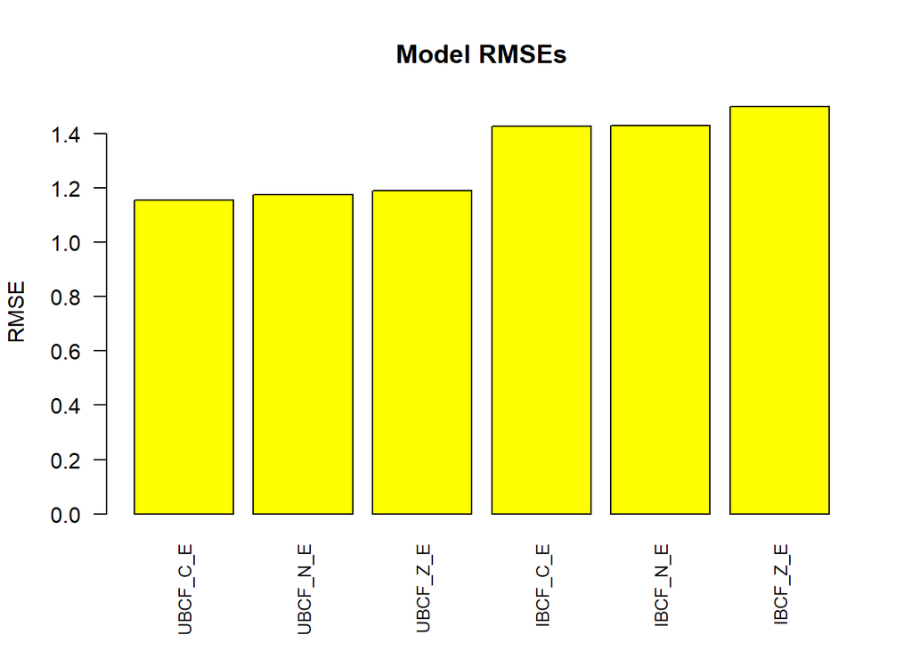

```r
barplot(c_res$RMSE, col = "yellow", main = "Model RMSEs", las = 2, ylab = "RMSE", horiz = FALSE,
        names.arg = rownames(c_res), cex.names=.8)
```

#### Evaluation result

From the above plot, it looks like the performance(prediction accuracy) of User-based Collaborative Fingering is better than Item-based Collaborative Filtering.

#### Save pre-trained models

Training a model is time consuming. The model object is stored in .rds format to save time and to be used by the App.

## Technical details

- The models are normalized using normalization settings, like ‘center’,‘Z-score’.
- The similarity metric used is Euclidean Distance.
- The prediction we are using on content-based algorithm(System I) is not based on a ‘weighted average’.

## Movie Recommendation App

- It is a shiny app with System I and System II algorithms
- System I (content based)
  - The app needs to take the input from users of their favorite genres, and display the result
  - System will provide two methods for System I
- System II (Collaborative Filtering)
  - The app need the users to rate as many movies as possible;
  - System will discover movies for the users by User-based or Item-based Collaborative Filtering models
- Setting
  - Select the algorithm for System I
  - Select the algorithm for System II

## Running the App

We run the following code on RStudio console using the following command:

**shiny::runApp(‘app’)**

## Conclusion

```r
Sys.time() - start_time
```

```
## Time difference of 1.828168 hours
```